# DataAnalysis

1. Identify and describe 2 data quality issues present in the dataset. Briefly propose strategies to address these issues. Document the steps taken and provide a summary of the data quality improvements.

```python
import pandas as pd
import matplotlib.pyplot as plt
import plotly.express as px
import seaborn as sns
import numpy as np
import unittest
import math
from scipy.stats import ttest_ind
from scipy.stats import shapiro
```

```python
def create_dateset():
    '''Read dataset and pre-process charge columns to replace missing values by zero and round to 2 places of decimal,
    Arguments - None,
    Return - created dataset as pandas dataframe'''
    input_table = pd.read_excel("Data Insights - Synthetic Dataset.xlsx", sheet_name = "Data Insights - Synthetic Datas")

    # for columns pertaining to charges, round off and replace missing values with zero
    numeric_columns = [ 'AccommodationCharge', 'CCU_Charges', 'ICU_Charge', 'TheatreCharge',  'ProsthesisCharge', 'OtherCharges',
       'BundledCharges']

    for column in numeric_columns:
        input_table.loc[:,column + "_Filled"]=input_table.loc[:,column].astype(float).round(2).fillna(0)

    # analyse and investigate scaling on pharmacy charge
    input_table.loc[:,"PharmacyCharge"]=input_table.loc[:,"PharmacyCharge"].apply(lambda x:str(x).replace("ERROR",'0')).astype(float)
    input_table.loc[:,"PharmacyCharge_Filled"]=input_table.loc[:,"PharmacyCharge"].astype(float).round(2).fillna(0)
    input_table.loc[:,"PharmacyCharge_Scaled"] = input_table.loc[:,"PharmacyCharge_Filled"].apply(lambda x:math.log(x) if x>0.01 else 0)

    return input_table
```

```python
# create dataset
input_table = create_dateset()
```

```python
def show_comparison (df, col1, col2, num_bins = 50):
    '''Performing comparison of distribution of columns col1 and col2,
    Also prints summary of missing data filled and summary statistics,
    Arguments - df is pandas dataframe with columns col1 and col2 for comparison, num_bins as number of bins in histogram,
    Return - None'''
    # Create subplots for two histograms
    fig, axes = plt.subplots(1, 2, figsize=(10, 5))

    # Calculate bin edges using numpy's linspace for filled columns
    bin_edges = np.linspace(df[col2].min(), df[col2].max(), num_bins + 1)

    sns.histplot(df[col1], bins=bin_edges, ax=axes[0])

    hist_data = sns.histplot(df[col2], bins=bin_edges, ax=axes[1])

    # Extract the counts from the histogram
    counts = hist_data.patches  # Patches are the rectangles that make up the histogram

    # Calculate maximum frequency
    max_frequency = max([patch.get_height() for patch in counts]) *1.1
    maxvalue = df[col2].max()

    # Set y-axis limits for both subplots
    axes[0].set_ylim([0, max_frequency])
    axes[0].set_xlim([0, maxvalue])
    axes[1].set_ylim([0, max_frequency])
    axes[1].set_xlim([0, maxvalue])
    axes[0].grid(visible=True, which='major', linestyle='--', linewidth=0.7, color='gray')  # Major gridlines
    axes[1].grid(visible=True, which='major', linestyle='--', linewidth=0.7, color='gray')  # Major gridlines

    # Show the plot
    plt.tight_layout()
    plt.show()

    # Before cleaning
    missing_before = df[col1].isnull().sum()

    # After cleaning
    missing_after = df[col2].isnull().sum()

    print("Missing data before:\n", missing_before)
    print("Missing data after:\n", missing_after)

    print("Summary before cleaning")
    print(df[col1].describe())

    print("Summary after cleaning")
    print(df[col2].describe())
```

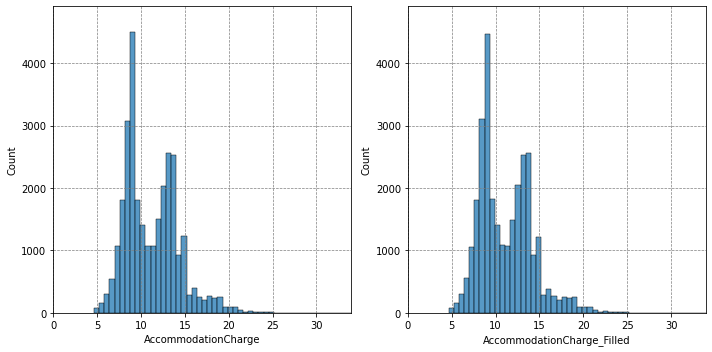

```
Missing data before:
 0
Missing data after:
 0
Summary before cleaning
count    30000.000000
mean        11.189211
std          3.068055
min          4.636378
25%          8.804736
50%         10.658766
75%         13.324689
max         33.944085
Name: AccommodationCharge, dtype: float64
Summary after cleaning
count    30000.000000
mean        11.189221
std          3.068058
min          4.640000
25%          8.800000
50%         10.660000
75%         13.320000
max         33.940000
Name: AccommodationCharge_Filled, dtype: float64
```

```python
show_comparison(input_table,"AccommodationCharge","AccommodationCharge_Filled")
```

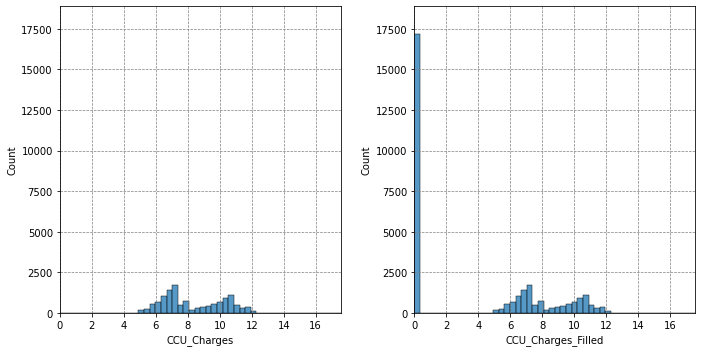

```
Missing data before:
 17167
Missing data after:
 0
Summary before cleaning
count    12833.000000
mean         8.344885
std          1.904278
min          5.019066
25%          6.808693
50%          7.765532
75%         10.201633
max         17.563012
Name: CCU_Charges, dtype: float64
Summary after cleaning
count    30000.000000
mean         3.569638
std          4.312475
min          0.000000
25%          0.000000
50%          0.000000
75%          7.240000
max         17.560000
Name: CCU_Charges_Filled, dtype: float64
```

```python
show_comparison(input_table,"CCU_Charges","CCU_Charges_Filled")
```

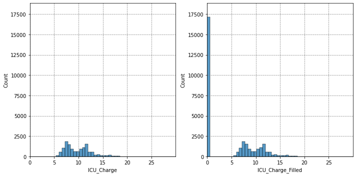

```
Missing data before:
 17138
Missing data after:
 0
Summary before cleaning
count    12862.000000
mean         9.839234
std          2.601829
min          5.708903
25%          7.696555
50%          9.513417
75%         11.591402
max         29.956644
Name: ICU_Charge, dtype: float64
Summary after cleaning
count    30000.000000
mean         4.218407
std          5.158868
min          0.000000
25%          0.000000
50%          0.000000
75%          8.590000
max         29.960000
Name: ICU_Charge_Filled, dtype: float64
```

```python
show_comparison(input_table,"ICU_Charge","ICU_Charge_Filled")
```

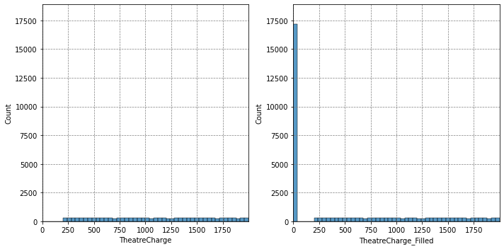

```
Missing data before:
 17164
Missing data after:
 0
Summary before cleaning
count    12836.000000
mean      1090.956923
std        518.080420
min        200.080000
25%        640.545000
50%       1085.280000
75%       1536.852500
max       1999.900000
Name: TheatreCharge, dtype: float64
Summary after cleaning
count    30000.000000
mean       466.784102
std        637.339069
min          0.000000
25%          0.000000
50%          0.000000
75%        935.985000
max       1999.900000
Name: TheatreCharge_Filled, dtype: float64
```

```python
show_comparison(input_table,"TheatreCharge","TheatreCharge_Filled")
```

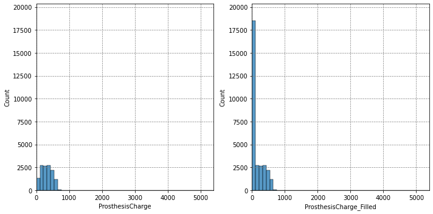

```
Missing data before:
 17151
Missing data after:
 0
Summary before cleaning
count    12849.000000
mean       317.982874
std        184.546634
min         50.040000
25%        181.948000
50%        311.064000
75%        437.697000
max       5391.750000
Name: ProsthesisCharge, dtype: float64
Summary after cleaning
count    30000.000000
mean       136.192094
std        198.356914
min          0.000000
25%          0.000000
50%          0.000000
75%        267.037500
max       5391.750000
Name: ProsthesisCharge_Filled, dtype: float64
```

```python
show_comparison(input_table,"ProsthesisCharge","ProsthesisCharge_Filled")
```

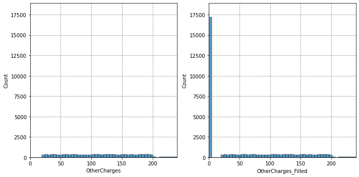

```
Missing data before:
 17181
Missing data after:
 0
Summary before cleaning
count    12819.000000
mean       112.844216
std         54.115388
min         20.000000
25%         65.960000
50%        112.940000
75%        158.625000
max        239.964000
Name: OtherCharges, dtype: float64
Summary after cleaning
count    30000.000000
mean        48.218338
std         66.087358
min          0.000000
25%          0.000000
50%          0.000000
75%         97.420000
max        239.960000
Name: OtherCharges_Filled, dtype: float64
```

```python
show_comparison(input_table,"OtherCharges","OtherCharges_Filled")
```

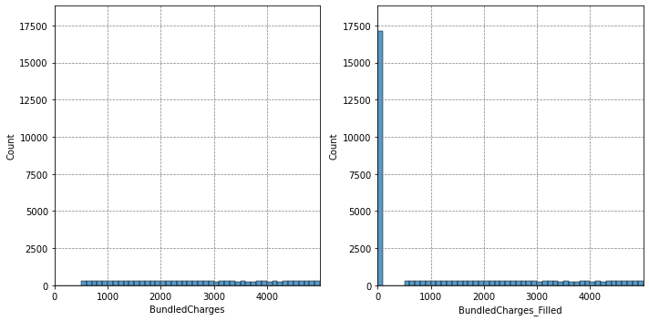

```
Missing data before:
 17106
Missing data after:
 0
Summary before cleaning
count    12894.000000
mean      2724.783963
std       1306.231291
min        500.050000
25%       1595.535000
50%       2698.535000
75%       3867.870000
max       4999.670000
Name: BundledCharges, dtype: float64
Summary after cleaning
count    30000.000000
mean      1171.112147
std       1597.777891
min          0.000000
25%          0.000000
50%          0.000000
75%       2335.385000
max       4999.670000
Name: BundledCharges_Filled, dtype: float64
```

```python
show_comparison(input_table,"BundledCharges","BundledCharges_Filled")
```

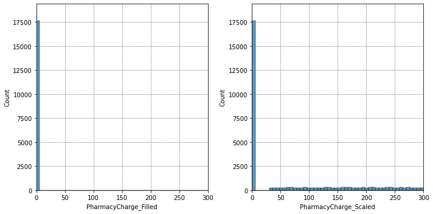

```
Missing data before:
 0
Missing data after:
 0
Summary before cleaning
count     3.000000e+04
mean     2.947087e+127
std      5.582371e+128
min       0.000000e+00
25%       0.000000e+00
50%       0.000000e+00
75%       4.395469e+59
max      2.130293e+130
Name: PharmacyCharge_Filled, dtype: float64
Summary after cleaning
count    30000.000000
mean        68.227829
std         95.511689
min          0.000000
25%          0.000000
50%          0.000000
75%        137.333080
max        300.092322
Name: PharmacyCharge_Scaled, dtype: float64
```

```python
show_comparison(input_table,"PharmacyCharge_Filled", "PharmacyCharge_Scaled")
```

Data Transformation and Analysis

Q2. Using the data provided create a feature that could be valuable for analysis or modelling. Explain the rationale behind the feature you created and how they might be useful for analysis.

Q6. Based on your analysis, identify two strategic insights that could help Ramsay improve hospital operations or patient care. Justify your insights with evidence from your data analysis.

```python
def classify_admission(episode):
    '''classify admission entries based on weeday working hours or otherwise to create categorical variable,
    Arguments: row entry for pandas dataframe,
    Return: Classification flag as Weekday_Workinghour, Weekday_NonWorkinghour or Weekend '''
    if episode['AdmissionDayOfWeek'] in [0,1,2,3,4]:
        if episode['AdmissionHour']>=9 and episode['AdmissionHour']<18:
            return 'Weekday_Workinghour'
        else:
            return 'Weekday_NonWorkinghour'
    else:
        return 'Weekend'

def classify_separation(episode):
    '''classify separation entries based on weeday working hours or otherwise to create categorical variable,
    Arguments: row entry for pandas dataframe,
    Return: Classification flag as Weekday_Workinghour, Weekday_NonWorkinghour or Weekend '''
    if episode['SeparationDayOfWeek'] in [0,1,2,3,4]:
        if episode['SeparationHour']>=9 and episode['SeparationHour']<18:
            return 'Weekday_Workinghour'
        else:
            return 'Weekday_NonWorkinghour'
    else:
        return 'Weekend'
```

```python
def transform_dataset(input_table):
    '''Function to create new features and transform existing features for analysis
    Arguement: input dataframe
    Return: Transformed dataset as pandas dataframe
    '''
    # convert admission provided id to string
    input_table['AdmissionProviderID'] = input_table['AdmissionProviderID'].astype(str)

    # combine date and time columns to create timestamp
    input_table.loc[:,"AdmissionTimestampStr"] = input_table.loc[:,'AdmissionDate'].astype(str) + " " +  input_table.loc[:,'AdmissionTime'].astype(str)
    input_table.loc[:,"AdmissionTimestamp"] = pd.to_datetime(input_table.loc[:,"AdmissionTimestampStr"])

    input_table.loc[:,"SeparationTimestampStr"] = input_table.loc[:,'SeparationDate'].astype(str) + " " +  input_table.loc[:,'SeparationTime'].astype(str)
    input_table.loc[:,"SeparationTimestamp"] = pd.to_datetime(input_table.loc[:,"SeparationTimestampStr"])

    #calculate length of stay based on admission and separation timestamps
    input_table.loc[:,"LengthofStay"] = input_table.loc[:,"SeparationTimestamp"] - input_table.loc[:,"AdmissionTimestamp"]
    input_table.loc[:,"LengthofStay_hours"] = input_table.loc[:,"LengthofStay"].dt.total_seconds() / 3600
    input_table.loc[:,"LengthofStay_days"] = input_table.loc[:,"LengthofStay_hours"] / 24

    #calculate total charge excluding pharmacy charges
    input_table.loc[:,"TotalCharges"] =  input_table.loc[:,'AccommodationCharge_Filled']+ input_table.loc[:,'CCU_Charges_Filled']+ input_table.loc[:,'TheatreCharge_Filled']+  input_table.loc[:,'ProsthesisCharge_Filled']+ input_table.loc[:,'OtherCharges_Filled']+ input_table.loc[:,'BundledCharges_Filled']

    #create feature for day, day name, hour, day of week, day of month, month, year
    input_table['AdmissionDayOfWeek'] = input_table['AdmissionTimestamp'].dt.dayofweek
    input_table['AdmissionDayName'] = input_table['AdmissionTimestamp'].dt.day_name()
    input_table['AdmissionHour'] = input_table['AdmissionTimestamp'].dt.hour

    input_table['SeparationDayOfWeek'] = input_table['SeparationTimestamp'].dt.dayofweek
    input_table['SeparationDayName'] = input_table['SeparationTimestamp'].dt.day_name()
    input_table['SeparationHour'] = input_table['SeparationTimestamp'].dt.hour

    input_table['AdmissionDay'] = input_table['AdmissionTimestamp'].dt.day
    input_table['AdmissionMonth'] = input_table['AdmissionTimestamp'].dt.month
    input_table['AdmissionYear'] = input_table['AdmissionTimestamp'].dt.year

    input_table['SeparationDay'] = input_table['SeparationTimestamp'].dt.day
    input_table['SeparationMonth'] = input_table['SeparationTimestamp'].dt.month
    input_table['SeparationYear'] = input_table['SeparationTimestamp'].dt.year

    # Define the order of days
    daysofweek = ['Monday', 'Tuesday','Wednesday', 'Thursday', 'Friday', 'Saturday','Sunday']
    day_dtype = pd.CategoricalDtype(categories=daysofweek, ordered=True)

    # convert day name to categorical variable
    input_table['AdmissionDayName'] = input_table['AdmissionDayName'].astype(day_dtype)
    input_table['SeparationDayName'] = input_table['SeparationDayName'].astype(day_dtype)

    # classification of admission based on weekend, weekday working hours or non-working hours
    input_table['Admission_Classification'] = input_table.apply(lambda x: classify_admission(x), axis=1)
    input_table['Separation_Classification'] = input_table.apply(lambda x: classify_separation(x), axis=1)

    #create binary variable to show if infant weight is provided
    input_table['InfantCase'] = input_table['InfantWeight'].apply(lambda x: 'Yes' if x>0 else 'No')

    #create binary variable to show if mechanical ventilation was used
    input_table['VentilationCase'] = input_table['HoursMechVentilation'].apply(lambda x: 'Yes' if x>0 else 'No')

    return input_table
```

```python
input_table = transform_dataset(input_table=input_table)
```

```python
def create_scatter_plot(df,x, y):
    '''Create scatter plot,
    Arguments - dataframe with x and y variables,
    Return - None'''
    # Create a scatter plot
    sns.scatterplot(data=df, x=x, y=y, color='blue')
    plt.xlabel(x)
    plt.ylabel(y)

    # Show the plot
    plt.show()
```

```python
def create_correlation_matrix(df):
    '''Calculate the correlation matrix and create heatmap,
    Argument - Dataframe with columns for calculation,
    Return - None'''
    correlation_matrix = df.corr()

    # Visualize the correlation matrix using a heatmap
    plt.figure(figsize=(8, 6))
    sns.heatmap(correlation_matrix, annot=True, cmap='coolwarm', fmt=".2f")
    plt.title('Correlation Matrix')
    plt.show()
```

```python
def create_box_plot(df, colx, coly):
    '''Create a box plot using Plotly Express
    Arguments: df is pandas dataframe, colx and coly are x and y columns respectively
    Return: None'''
    fig = px.box(df, x=colx, y=coly, title='Distribution of ' + coly + ' by ' + colx)
    fig.show()

def comparison_summary(df,colx):
    '''Create a summary table of median of length of stay, median of total charge and count of episodes.
    Arguments: df is pandas dataframe, colx and coly are x and y columns respectively
    Return: None'''
    df_by_col = pd.pivot_table(df,index=[colx], aggfunc={'LengthofStay_hours':'median', 'TotalCharges':"median",'episode_id':'count'}).reset_index()
    df_by_col.columns = [colx,"Median_Duration", "Median_Charge","Count_Cases"]
    print(df_by_col)
```

```python
def plot_mean_comparison(df, colx, coly):
    '''Creates comparison plot for numerical distribution by given columns
    Arguments - dataframe and selected columns
    Returns - None'''
    df_by_col = pd.pivot_table(df,index=[colx], aggfunc={coly:'mean'}).reset_index()
    df_by_col.columns = [colx,"Mean_" + coly]
    fig = px.bar(df_by_col, x=colx, y="Mean_" + coly, text="Mean_" + coly, title = "Distribution of " + coly + ' by '+colx)
    fig.update_traces(textposition='inside')
    fig.update_layout(
    xaxis_title_text=colx,
    yaxis_title_text='Mean of ' + coly)
    fig.show()

def plot_count_comparison(df, colx, coly):
    '''Creates comparison plot of count by given columns
    Arguments - dataframe and selected columns
    Returns - None'''
    df_by_col = pd.pivot_table(df,index=[colx], aggfunc={coly:'count'}).reset_index()
    df_by_col.columns = [colx,"Count_" + coly]
    fig = px.bar(df_by_col, x=colx, y="Count_" + coly, text="Count_" + coly, title = "Distribution of " + coly + ' by '+colx)
    fig.update_traces(textposition='inside')
    fig.update_layout(
    xaxis_title_text=colx,
    yaxis_title_text='Count of ' + coly)
    fig.show()
```

```python
def compare_plots(df, col):
    '''Create comparison plots and summary for Length of stay, Total charge and number of episodes,
    Arguments - dataframe with column for comparison,
    Return - None'''
    create_box_plot(df, colx = col, coly='LengthofStay_hours')
    create_box_plot(df, colx = col, coly='TotalCharges')
    plot_count_comparison(df, colx = col, coly='episode_id')
    comparison_summary(df,colx = col)
```

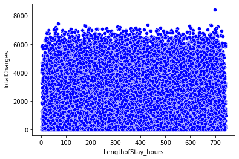

```python
create_scatter_plot(input_table, x="LengthofStay_hours", y="TotalCharges")
```

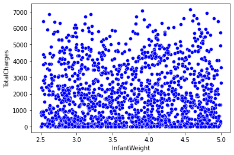

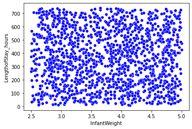

```python
create_scatter_plot(input_table, x="InfantWeight", y="TotalCharges")
create_scatter_plot(input_table, x="InfantWeight", y="LengthofStay_hours")
```